# Non Linear Modelling

```r
library(ISLR)
#attach(Wage)
names(Wage)
```

```
 [1] "year"       "age"        "sex"        "maritl"     "race"       "education"  "region"     "jobclass"
 [9] "health"     "health_ins" "logwage"    "wage"
```

```r
summary(Wage)
```

```
      year           age               sex                    maritl           race
 Min.   :2003   Min.   :18.00   1. Male  :3000   1. Never Married: 648   1. White:2480
 1st Qu.:2004   1st Qu.:33.75   2. Female:   0   2. Married      :2074   2. Black: 293
 Median :2006   Median :42.00                    3. Widowed      :  19   3. Asian: 190
 Mean   :2006   Mean   :42.41                    4. Divorced     : 204   4. Other:  37
 3rd Qu.:2008   3rd Qu.:51.00                    5. Separated    :  55
 Max.   :2009   Max.   :80.00

              education                     region               jobclass               health      health_ins
 1. < HS Grad      :268   2. Middle Atlantic   :3000   1. Industrial :1544   1. <=Good     : 858   1. Yes:2083
 2. HS Grad        :971   1. New England       :   0   2. Information:1456   2. >=Very Good:2142   2. No : 917
 3. Some College   :650   3. East North Central:   0
 4. College Grad   :685   4. West North Central:   0
 5. Advanced Degree:426   5. South Atlantic    :   0
                          6. East South Central:   0
                          (Other)              :   0
    logwage           wage
 Min.   :3.000   Min.   : 20.09
 1st Qu.:4.447   1st Qu.: 85.38
 Median :4.653   Median :104.92
 Mean   :4.654   Mean   :111.70
 3rd Qu.:4.857   3rd Qu.:128.68
 Max.   :5.763   Max.   :318.34
```

```r
head(Wage)
```

|  | year | age | sex | maritl | race | education | region | jobclass | health | health_ins | logwage | wage |
| --- | --- | --- | --- | --- | --- | --- | --- | --- | --- | --- | --- | --- |
| 231655 | 2006 | 18 | 1. Male | 1. Never Married | 1. White | 1. < HS Grad | 2. Middle Atlantic | 1. Industrial | 1. <=Good | 2. No | 4.318063 | 75.04315 |
| 86582 | 2004 | 24 | 1. Male | 1. Never Married | 1. White | 4. College Grad | 2. Middle Atlantic | 2. Information | 2. >=Very Good | 2. No | 4.255273 | 70.47602 |
| 161300 | 2003 | 45 | 1. Male | 2. Married | 1. White | 3. Some College | 2. Middle Atlantic | 1. Industrial | 1. <=Good | 1. Yes | 4.875061 | 130.98218 |
| 155159 | 2003 | 43 | 1. Male | 2. Married | 3. Asian | 4. College Grad | 2. Middle Atlantic | 2. Information | 2. >=Very Good | 1. Yes | 5.041393 | 154.68529 |
| 11443 | 2005 | 50 | 1. Male | 4. Divorced | 1. White | 2. HS Grad | 2. Middle Atlantic | 2. Information | 1. <=Good | 1. Yes | 4.318063 | 75.04315 |
| 376662 | 2008 | 54 | 1. Male | 2. Married | 1. White | 4. College Grad | 2. Middle Atlantic | 2. Information | 2. >=Very Good | 1. Yes | 4.845098 | 127.11574 |

```r
dim(Wage)
```

```
[1] 3000   12
```

## Polynomial Regression and Step Functions

**poly function** Poly function generates orthogonal polynomials. If you want to consider poly as black box function then don’t be bothered about orthogonal polynomials.

The poly function returns a matrix where each row corresponds to a training point and columns are basis of orthogonal polynomials. Each column is a linear combination of age, age^2, age^3, age^4.

**Linear combination according to wikipedia :**

```
In mathematics, a linear combination is an expression constructed from a set of terms by multiplying each term by a constant and adding the results (e.g. a linear combination of x and y would be any expression of the form ax + by, where a and b are constants)
```

```r
head(poly(Wage$age, 4))
```

```
                 1            2             3            4
[1,] -0.0386247992  0.055908727 -0.0717405794  0.086729854
[2,] -0.0291326034  0.026298066 -0.0145499511 -0.002599280
[3,]  0.0040900817 -0.014506548 -0.0001331835  0.014480093
[4,]  0.0009260164 -0.014831404  0.0045136682  0.012657507
[5,]  0.0120002448 -0.009815846 -0.0111366263  0.010211456
[6,]  0.0183283753 -0.002073906 -0.0166282799 -0.001314381
```

With raw = TRUE, we can obtain age, age^2, age^3, age^4.

```r
head(poly(Wage$age, 4, raw = T))
```

```
      1    2      3       4
[1,] 18  324   5832  104976
[2,] 24  576  13824  331776
[3,] 45 2025  91125 4100625
[4,] 43 1849  79507 3418801
[5,] 50 2500 125000 6250000
[6,] 54 2916 157464 8503056
```

```r
fit = lm(wage~poly(age, 4), data = Wage)
coef(summary(fit))
```

```
                Estimate Std. Error    t value     Pr(>|t|)
(Intercept)    111.70361  0.7287409 153.283015 0.000000e+00
poly(age, 4)1  447.06785 39.9147851  11.200558 1.484604e-28
poly(age, 4)2 -478.31581 39.9147851 -11.983424 2.355831e-32
poly(age, 4)3  125.52169 39.9147851   3.144742 1.678622e-03
poly(age, 4)4  -77.91118 39.9147851  -1.951938 5.103865e-02
```

We can use poly with raw = T, the choice of basis functions may effect coeff estimates but overall model remains the same.

```r
fit2 <- lm(wage ~ poly(age, 4, raw = T), data = Wage)
coef(summary(fit2))
```

```
                            Estimate   Std. Error   t value     Pr(>|t|)
(Intercept)            -1.841542e+02 6.004038e+01 -3.067172 0.0021802539
poly(age, 4, raw = T)1  2.124552e+01 5.886748e+00  3.609042 0.0003123618
poly(age, 4, raw = T)2 -5.638593e-01 2.061083e-01 -2.735743 0.0062606446
poly(age, 4, raw = T)3  6.810688e-03 3.065931e-03  2.221409 0.0263977518
poly(age, 4, raw = T)4 -3.203830e-05 1.641359e-05 -1.951938 0.0510386498
```

The fitted value remains same.

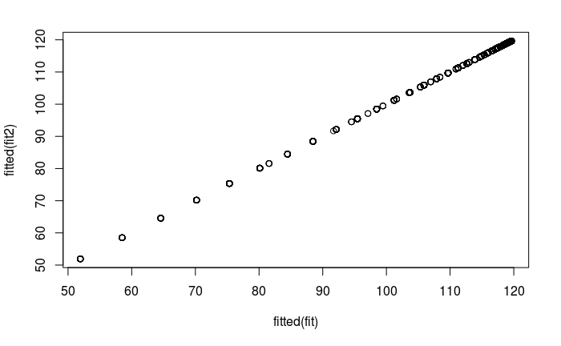

```r
plot(fitted(fit), fitted(fit2))
```

The formula in R is quite flexible. We can use formula like below `

```r
fit3 <- lm(wage ~ I(age) + I(age ^ 2) + I(age ^ 3) + I(age ^ 4), data = Wage)
coef(summary(fit3))
```

```
                 Estimate   Std. Error   t value     Pr(>|t|)
(Intercept) -1.841542e+02 6.004038e+01 -3.067172 0.0021802539
I(age)       2.124552e+01 5.886748e+00  3.609042 0.0003123618
I(age^2)    -5.638593e-01 2.061083e-01 -2.735743 0.0062606446
I(age^3)     6.810688e-03 3.065931e-03  2.221409 0.0263977518
I(age^4)    -3.203830e-05 1.641359e-05 -1.951938 0.0510386498
```

In above formula I() serves as a wrapper to protect power terms as ^ has a special meaning in formula. Any function call like cbind inside formula also serves as a wrapper.

```r
fit4 <- lm(wage ~ cbind(age, age^2, age^3, age^4))
coef(summary(fit4))
```

```
                                        Estimate   Std. Error   t value     Pr(>|t|)
(Intercept)                        -1.841542e+02 6.004038e+01 -3.067172 0.0021802539
cbind(age, age^2, age^3, age^4)age  2.124552e+01 5.886748e+00  3.609042 0.0003123618
cbind(age, age^2, age^3, age^4)    -5.638593e-01 2.061083e-01 -2.735743 0.0062606446
cbind(age, age^2, age^3, age^4)     6.810688e-03 3.065931e-03  2.221409 0.0263977518
cbind(age, age^2, age^3, age^4)    -3.203830e-05 1.641359e-05 -1.951938 0.0510386498
```

Creating grid values for age at which we want predictions using predict and specifying we need standard errors as well.

```r
age.range <- range(age)
age.grid <- seq(from = age.range[1], to = age.range[2])
pred <- predict(fit, newdata = list(age = age.grid), se = TRUE)
se.bands <- cbind(pred$fit + 2*pred$se.fit, pred$fit - 2*pred$se.fit)
head(se.bands)
```

```
      [,1]     [,2]
1 62.52799 41.33491
2 67.23827 49.75522
3 71.75608 57.38768
4 76.09436 64.27111
5 80.26558 70.44323
6 84.27774 75.94470
```

```r
plot(age, wage, xlim = age.range, cex = .5, col = "darkgrey")
title("Degree 4 Polynomial")
```

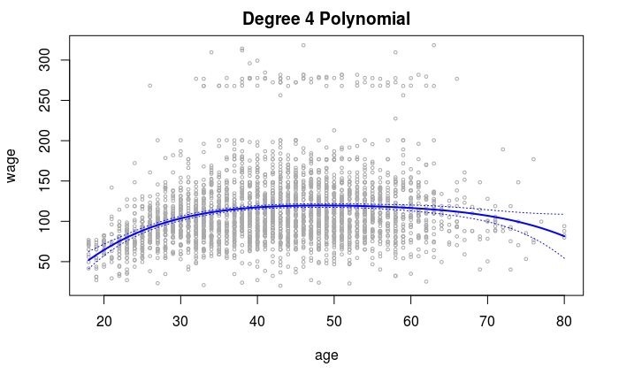

```r
lines(age.grid,pred$fit, lwd = 2, col = "blue")
matlines(age.grid, se.bands, lwd = 1, col = "blue", lty = 3)
```

mar and oma arguments in par are used tocontrol margins.

poly function without raw = TRUE parameter produces orthogonal set of basis functions. But, it doesn’t effect the model obtained in meaningful way.

```r
pred2 <- predict(fit2, newdata = list(age = age.grid), se = TRUE)
max(abs(pred$fit - pred2$fit))
```

```
[1] 7.81597e-11
```

### Hypothesis Tests

**ANOVA tests**: In order to determine which degree polynomial to use we can use hypothesis test. We can create a hypothesis that M1, a simpler model is sufficient to explain the reationship between predictor and response or more complex model M2 is required using ANOVA, F-test. The predictors in M1 must be subset of M2.

```r
fit1 <- lm(wage~age)
fit2 <- lm(wage~poly(age, 2))
fit3 <- lm(wage~poly(age, 3))
fit4 <- lm(wage~poly(age, 4))
fit5 <- lm(wage~poly(age, 5))
anova(fit1, fit2, fit3, fit4, fit5)
```

```
Analysis of Variance Table

Model 1: wage ~ age
Model 2: wage ~ poly(age, 2)
Model 3: wage ~ poly(age, 3)
Model 4: wage ~ poly(age, 4)
Model 5: wage ~ poly(age, 5)
  Res.Df     RSS Df Sum of Sq        F    Pr(>F)
1   2998 5022216
2   2997 4793430  1    228786 143.5931 < 2.2e-16 ***
3   2996 4777674  1     15756   9.8888  0.001679 **
4   2995 4771604  1      6070   3.8098  0.051046 .
5   2994 4770322  1      1283   0.8050  0.369682
---
Signif. codes:  0 ‘***’ 0.001 ‘**’ 0.01 ‘*’ 0.05 ‘.’ 0.1 ‘ ’ 1
```

1. The p-value comparing the linear model 1 to quadratic model 2 is close to zero which means that linear fit is not sufficient.
2. The p-value comparing the quadratic model 2 to cubic model 3 is very low which means quadratic model is not sufficient.
3. The p-value comparing the cubic model to quartic model is 0.05 and comparing model 4 with model 5 the p-value is 0.369 thus degree 5 polynomial is not required.

**Conclusion** : the quartic and cubic polynomial appear to provide reasonable fit.

Instead of using ANOVA we could have used p-values obtained by exploiting the fact that poly function produces orthogonal polynomials. As probability associated with each coefficient is same as anova.

It is because of fact that orthogonal polynomial of degree n is obtained by orthogonal polynomial of degree n-1.

```r
coef(summary(fit5))
```

```
                Estimate Std. Error     t value     Pr(>|t|)
(Intercept)    111.70361  0.7287647 153.2780243 0.000000e+00
poly(age, 5)1  447.06785 39.9160847  11.2001930 1.491111e-28
poly(age, 5)2 -478.31581 39.9160847 -11.9830341 2.367734e-32
poly(age, 5)3  125.52169 39.9160847   3.1446392 1.679213e-03
poly(age, 5)4  -77.91118 39.9160847  -1.9518743 5.104623e-02
poly(age, 5)5  -35.81289 39.9160847  -0.8972045 3.696820e-01
```

```r
summary(fit5)
```

```
Call:
lm(formula = wage ~ poly(age, 5))

Residuals:
    Min      1Q  Median      3Q     Max
-99.049 -24.386  -5.028  15.344 202.886

Coefficients:
               Estimate Std. Error t value Pr(>|t|)
(Intercept)    111.7036     0.7288 153.278  < 2e-16 ***
poly(age, 5)1  447.0679    39.9161  11.200  < 2e-16 ***
poly(age, 5)2 -478.3158    39.9161 -11.983  < 2e-16 ***
poly(age, 5)3  125.5217    39.9161   3.145  0.00168 **
poly(age, 5)4  -77.9112    39.9161  -1.952  0.05105 .
poly(age, 5)5  -35.8129    39.9161  -0.897  0.36968
---
Signif. codes:  0 ‘***’ 0.001 ‘**’ 0.01 ‘*’ 0.05 ‘.’ 0.1 ‘ ’ 1

Residual standard error: 39.92 on 2994 degrees of freedom
Multiple R-squared:  0.08651,   Adjusted R-squared:  0.08498
F-statistic: 56.71 on 5 and 2994 DF,  p-value: < 2.2e-16
```

NOTE : the coefficients and p-value are different when using raw = TRUE. This is because predictors age^2 and age are highly correlated while in orthogonal age^2 only captures the quadratic part that has not been captured by linear term.

## Polynomial Logistic Regression

```r
fit <- glm(I(wage>250)~poly(age, 4), family = binomial)
fit
```

```
Call:  glm(formula = I(wage > 250) ~ poly(age, 4), family = binomial)

Coefficients:
  (Intercept)  poly(age, 4)1  poly(age, 4)2  poly(age, 4)3  poly(age, 4)4
       -4.301         71.964        -85.773         34.163        -47.401

Degrees of Freedom: 2999 Total (i.e. Null);  2995 Residual
Null Deviance:      730.5
Residual Deviance: 701.2    AIC: 711.2
```

wage>250 evaluates to TRUEs and FALSEs which glm coerces to 0s and 1s.

```r
pred <- predict(fit, newdata = list(age = age.grid), se = T)
```

By default, prediction type for a glm model is type = ‘link’. This means we get predictions for the logit which means we fit a model of the form.

```
                                        log(Pr(Y=1/X)/(1-Pr(Y=1/X))) = XB
```

In order to obtain confidence intervals for P(Y=1/X) we will use transformations.

```
                                        P(Y=1/X) = exp(XB)/(1+exp(XB))
```

```r
pfit <- exp(pred$fit)/(1+exp(pred$fit))
se.bands.logit <- cbind(pred$fit + 2*pred$se.fit, pred$fit - 2*pred$se.fit)
se.bands <- exp(se.bands.logit)/(1+exp(se.bands.logit))
```

**NOTE:** We could have directly computed probabilities using type = “response”.

```r
plot(age, I(wage>250), xlim = age.range, ylim = c(0, .2))
points(jitter(age), I((wage>250)/5), cex = .5, pch = "|", col = 'darkgray')
```

```r
title("Degree 4 Polynomial")
lines(age.grid, pfit, lwd = 2, col = "blue")
```

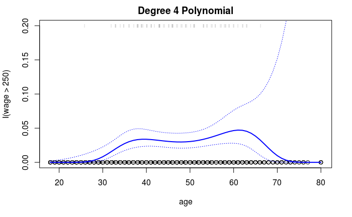

```r
matlines(age.grid, se.bands, lwd = 1, col = "blue", lty = 3)
```

Jitter function jitter age values a bit so that observations with same age value do not cover each other up. This is called a *rug plot*. Age values corresponding to wage above 250 are shown as gray marks on top and age values corresponding to wage below 250 are shown as gray marks on bottom.

**Cut function :**

```r
table(cut(age, 4))
```

```
(17.9,33.5]   (33.5,49]   (49,64.5] (64.5,80.1]
        750        1399         779          72
```

```r
fit <- lm(wage ~ cut(age, 4))
summary(fit)
```

```
Call:
lm(formula = wage ~ cut(age, 4))

Residuals:
    Min      1Q  Median      3Q     Max
-98.126 -24.803  -6.177  16.493 200.519

Coefficients:
                       Estimate Std. Error t value Pr(>|t|)
(Intercept)              94.158      1.476  63.790   <2e-16 ***
cut(age, 4)(33.5,49]     24.053      1.829  13.148   <2e-16 ***
cut(age, 4)(49,64.5]     23.665      2.068  11.443   <2e-16 ***
cut(age, 4)(64.5,80.1]    7.641      4.987   1.532    0.126
---
Signif. codes:  0 ‘***’ 0.001 ‘**’ 0.01 ‘*’ 0.05 ‘.’ 0.1 ‘ ’ 1

Residual standard error: 40.42 on 2996 degrees of freedom
Multiple R-squared:  0.0625,    Adjusted R-squared:  0.06156
F-statistic: 66.58 on 3 and 2996 DF,  p-value: < 2.2e-16
```

The cut produces chooses 4 cuts as shown by table. We can use our own break points using breaks. lm() function creates dummy variables for use in the regression. The age<33.5 is left out, so the intercept represents the average salary of people below age 33.5 and other coefficients can be treated as average additional salary under those age groups.